# UEFA Champions League Simulation

## Data Overview

The following data was gathered using the `worldfootballR` library to scrape 2019-20 UEFA Champions League group stage and knockout game results and the 2018-19 domestic league results for the 32 competing teams across 16 individual league competitions[^1] from fbref.com.

## Data Pre-processing

In order to use the domestic competition and UEFA Champions League matchup data scraped from [fbref.com](https://www.fbref.com/)[^2] with the Bradley-Terry package, `BradleyTerry2`, the raw data must first be cleaned, parsed, and reformated into the package’s expected format. This code follows that found in Lecture 12, particularly when refactoring home and away win data into a trainable DataFrame.

With the leagues all concatenated together, we can check to see the distribution of the complete DataFrame’s members.

| Competition_Name | Gender | Country | Season_End_Year | Round | Wk | Day | Date | Time | Home | HomeGoals | Away | AwayGoals | Attendance | Venue | Referee | Notes | MatchURL |
| --- | --- | --- | --- | --- | --- | --- | --- | --- | --- | --- | --- | --- | --- | --- | --- | --- | --- |
| Süper Lig | M | TUR | 2019 | NA | 28 | Sun | 2019-04-14 | 16:00:00 | Yeni Mal'spor | 1 | Alanyaspor | 1 | NA | Yeni Malatya Stadyumu | Serkan Çınar | NA | https://fbref.com/en/matches/c132193e/Yeni-Malatyaspor-Alanyaspor-April-14-2019-Super-Lig |
| La Liga | M | ESP | 2019 | NA | 22 | Sun | 2019-02-03 | 12:00:00 | Villarreal | 2 | Espanyol | 2 | 15476 | Estadio de la Cerámica | Guillermo Cuadra | NA | https://fbref.com/en/matches/9172e3c8/Villarreal-Espanyol-February-3-2019-La-Liga |
| Ligue 1 | M | FRA | 2019 | Ligue 1 | 35 | Fri | 2019-05-03 | 20:45:00 | Strasbourg | 1 | Marseille | 1 | 25962 | Stade de la Meinau | Jérôme Miguelgorry | NA | https://fbref.com/en/matches/3149818a/Strasbourg-Marseille-May-3-2019-Ligue-1 |
| La Liga | M | ESP | 2019 | NA | 1 | Sat | 2018-08-18 | 18:15:00 | Celta Vigo | 1 | Espanyol | 1 | 16215 | Estadio de Balaídos | Santiago Jaime | NA | https://fbref.com/en/matches/a8d60ff6/Celta-Vigo-Espanyol-August-18-2018-La-Liga |
| Serbian SuperLiga | M | SRB | 2019 | Regular season | 13 | Sun | 2018-10-28 | 16:30:00 | Mačva Šabac | 0 | Red Star | 2 | 5000 | Stadion FK Mačva | Ilja Brdar | NA | https://fbref.com/en/matches/296ba160/Macva-Sabac-Red-Star-October-28-2018-Serbian-SuperLiga |
| Eredivisie | M | NED | 2019 | Eredivisie | 6 | Sat | 2018-09-22 | 18:30:00 | Fortuna Sittard | 4 | Willem II | 4 | 8537 | Fortuna Sittard Stadion | Allard Lindhout | NA | https://fbref.com/en/matches/41f2a6a6/Fortuna-Sittard-Willem-II-September-22-2018-Eredivisie |
| La Liga | M | ESP | 2019 | NA | 36 | Sat | 2019-05-04 | 13:00:00 | Levante | 4 | Rayo Vallecano | 1 | 19868 | Estadio Ciudad de Valencia | Daniel Ask | NA | https://fbref.com/en/matches/05f0ac3a/Levante-Rayo-Vallecano-May-4-2019-La-Liga |
| Primeira Liga | M | POR | 2019 | NA | 28 | Sun | 2019-04-07 | 15:00:00 | Vitória Setúbal | 1 | Marítimo | 0 | 2702 | Estádio do Bonfim | Manuel Oliveira | NA | https://fbref.com/en/matches/1f7bc799/Vitoria-Setubal-Maritimo-April-7-2019-Primeira-Liga |
| Serie A | M | ITA | 2019 | NA | 27 | Sun | 2019-03-10 | 15:00:00 | Sampdoria | 1 | Atalanta | 2 | 20896 | Stadio Comunale Luigi Ferraris | Michael Fabbri | NA | https://fbref.com/en/matches/38ee4d56/Sampdoria-Atalanta-March-10-2019-Serie-A |
| Ukrainian Premier League | M | UKR | 2019 | Regular season | 16 | Sun | 2018-11-25 | 19:30:00 | FC Oleksandriya | 2 | Dynamo Kyiv | 1 | 2478 | KSK Nika | Ihor Paskhal | NA | https://fbref.com/en/matches/bbe5bffb/FC-Oleksandriya-Dynamo-Kyiv-November-25-2018-Ukrainian-Premier-League |

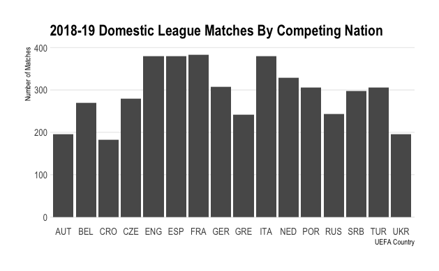

```
# CODE FROM LECTURE 12

# results <-

#  no_ties |>

#  dplyr::rename(home.team = Home, away.team = Opponent) |>

#  dplyr::group_by(home.team, away.team) |>

#  dplyr::summarise(

#    home.win = sum(Home_Winner),

#    away.win = sum(Opp_Winner), .groups = 'drop') |>

#  dplyr::mutate(

#    home.team = factor(home.team, levels = unik_teams),

#    away.team = factor(away.team,levels = unik_teams))

no_ties = all %>% filter(HomeGoals != AwayGoals) %>%

  filter(!str_detect(Round, "play-offs") | is.na(Round)) %>% ## removing matchups in pro/rel playoffs, otherwise we'll see skewed strengths for those leagues

  mutate(Home_Winner = case_when(HomeGoals > AwayGoals ~ 1, .default=0),

         Opp_Winner = case_when(AwayGoals > HomeGoals ~ 1, .default=0))

unik_teams = sort(unique(c(no_ties$Home, no_ties$Away)))

results = no_ties %>%

  rename(home.team = Home, away.team = Away) %>%

  group_by(home.team, away.team) %>%

  dplyr::summarise(

    home.win = sum(Home_Winner),

    away.win = sum(Opp_Winner), .groups = 'drop') |>

  dplyr::mutate(

    home.team = factor(home.team, levels = unik_teams),

    away.team = factor(away.team, levels = unik_teams))

results[sample(1:nrow(results),size=10),]
```

| home.team | away.team | home.win | away.win |
| --- | --- | --- | --- |
| Leverkusen | Bayern Munich | 1 | 0 |
| PSV Eindhoven | Vitesse | 1 | 0 |
| Real Sociedad | Villarreal | 0 | 1 |
| Partizan | Mladost Lučani | 1 | 0 |
| Nice | Dijon | 0 | 1 |
| Austria Wien | RB Salzburg | 0 | 2 |
| Benfica | Feirense | 1 | 0 |
| Real Madrid | Valladolid | 1 | 0 |
| Girona | Betis | 0 | 1 |
| Ural | Anzhi | 0 | 1 |

With the data now in place and formatted for `BradleyTerry2`, we can begin fitting a Bradley-Terry model to determine latent team strength for all clubs competing in the 2019-20 UEFA Champions League group stage based on their domestic league results.

## Fitting Bradley-Terry Model Based on Domestic League Results

For this problem, we’ll use a weak baseline as a reference, which we found to best fit the team strengths without many missing values, due to disconnected graphs.

Throughout our trials, we found that the Russian team Yenisey, which placed 16th out of 16 teams in the Russian Premier League throughout the 2018-19 season, resulted in a well-defined range of team strengths.[^3]

```
fit <-
  BradleyTerry2::BTm(
    outcome = cbind(home.win, away.win),
    player1 = home.team, player2 = away.team,
    refcat = "Yenisey",
    data = results)
summary(fit)
```

```
Call:
BradleyTerry2::BTm(outcome = cbind(home.win, away.win), player1 = home.team,
    player2 = away.team, refcat = "Yenisey", data = results)

Coefficients: (15 not defined because of singularities)
                       Estimate Std. Error z value Pr(>|z|)
..Admira             -1.699e+00  7.224e-01  -2.351 0.018703 *
..ADO Den Haag        4.839e-01  5.791e-01   0.836 0.403390
..AEK Athens          1.817e+00  7.762e-01   2.341 0.019250 *
..Ajax                2.547e+00  7.054e-01   3.610 0.000306 ***
..Akhisarspor        -1.146e+00  6.298e-01  -1.820 0.068752 .
..Akhmat Grozny       1.802e+00  7.497e-01   2.404 0.016207 *
..Alanyaspor         -3.666e-01  5.764e-01  -0.636 0.524825
..Alavés              3.696e-01  5.777e-01   0.640 0.522352
..Almere City        -3.180e+01  2.058e+03  -0.015 0.987674
..Amiens             -5.772e-03  6.290e-01  -0.009 0.992678
..Anderlecht          7.644e-01  6.148e-01   1.243 0.213741
..Angers              6.001e-01  6.662e-01   0.901 0.367694
..Ankaragücü         -4.069e-01  5.677e-01  -0.717 0.473604
..Antalyaspor        -1.961e-01  5.593e-01  -0.351 0.725882
..Antwerp             9.371e-01  6.072e-01   1.543 0.122744
..Anzhi               2.166e-01  7.402e-01   0.293 0.769815
..Apollon Smyrnis    -1.927e+00  9.077e-01  -2.123 0.033748 *
..Aris                1.009e+00  7.079e-01   1.425 0.154217
..Arsenal             6.169e-01  5.923e-01   1.041 0.297644
..Arsenal Tula        2.234e+00  7.713e-01   2.896 0.003779 **
..Arsenal-Kyiv       -1.628e+00  6.876e-01  -2.368 0.017877 *
..Asteras Tripoli     2.133e-01  7.551e-01   0.283 0.777549
..Atalanta            1.094e+00  5.904e-01   1.853 0.063941 .
..Athletic Club       4.668e-01  5.969e-01   0.782 0.434186
..Atlético Madrid     1.678e+00  6.414e-01   2.616 0.008887 **
..Atromitos           1.573e+00  7.679e-01   2.048 0.040541 *
..Augsburg           -1.408e+00  6.414e-01  -2.196 0.028115 *
..Austria Wien       -5.992e-01  6.383e-01  -0.939 0.347870
..Aves                8.123e-02  6.295e-01   0.129 0.897329
..AZ Alkmaar          1.017e+00  6.115e-01   1.664 0.096204 .
..B-SAD               7.097e-01  7.094e-01   1.000 0.317148
..Bačka Palanka       7.686e-03  6.557e-01   0.012 0.990647
..Baník Ostrava      -1.863e+00  6.710e-01  -2.777 0.005491 **
..Barcelona           2.540e+00  7.526e-01   3.375 0.000737 ***
```

[output cut: 162 more lines]

```
..RB Salzburg         2.152e+00  8.667e-01   2.483 0.013033 *
..Real Madrid         9.388e-01  5.710e-01   1.644 0.100187
..Real Sociedad       4.991e-01  5.733e-01   0.871 0.383993
..Red Star            5.871e+00  1.375e+00   4.271 1.95e-05 ***
 [ reached 'max' / getOption("max.print") -- omitted 77 rows ]
---
Signif. codes:  0 ‘***’ 0.001 ‘**’ 0.01 ‘*’ 0.05 ‘.’ 0.1 ‘ ’ 1

(Dispersion parameter for binomial family taken to be 1)

    Null deviance: 4691.2  on 3323  degrees of freedom
Residual deviance: 3461.3  on 3061  degrees of freedom
AIC: 4069.8

Number of Fisher Scoring iterations: 14
```

```
lambda_hat = as.data.frame(BradleyTerry2::BTabilities(fit))
lambda_hat = lambda_hat %>% drop_na() %>% arrange(desc(ability))
lambda_hat = rownames_to_column(lambda_hat) %>% rename(team = rowname)
lambda_hat
```

| team | ability | s.e. |
| --- | --- | --- |
| PAOK | 16.865424258 | 246.2486803 |
| RKC Waalwijk | 15.172802609 | 1455.3976480 |
| NEC Nijmegen | 15.172802609 | 1455.3983351 |
| FC Kolos Kovalivka | 14.141751526 | 1455.3976976 |
| Red Star | 5.870847663 | 1.3746661 |
| Radnički Niš | 5.040786848 | 1.2521379 |
| Olympiacos | 3.768760706 | 1.1806422 |
| Dinamo Zagreb | 3.354133394 | 0.9317167 |
| Liverpool | 3.326899235 | 1.1183687 |
| Shakhtar | 3.308790803 | 1.1540573 |

[output cut: 253 more lines]

Given the summary of the Bradley-Terry model and its resulting team strengths, it seems that the results were relatively sensitive to positive results for teams in skewed competitions. In other words, in leagues that are typically dominated by a small number of teams (Greece, Czechia), results over and by the top teams in the competitions were “rewarded” more than their counterparts in other “fairer” competitions (England, Spain). Subjectively, clubs like Red Star typically dominant their domestic competition, which means we would expect a high “ability” assignment, like we see in this model.

For the sake of our project, we’ll only focus on the strengths of the clubs competing in the 2019-20 UEFA Champions League group stages. From this, we see the aforementioned Red Star leading in “domestic strength”, along with other dominant teams from smaller nations, like Olympiacos from Greece and Dinamo Zagreb from Croatia. This aligns with our prior assumptions.

| Home | Country | ability | s.e. |
| --- | --- | --- | --- |
| Red Star | rs | 5.8708477 | 1.3746661 |
| Olympiacos | gr | 3.7687607 | 1.1806422 |
| Dinamo Zagreb | hr | 3.3541334 | 0.9317167 |
| Liverpool | eng | 3.3268992 | 1.1183687 |
| Shakhtar | ua | 3.3087908 | 1.1540573 |
| Benfica | pt | 3.1346783 | 0.8328164 |
| Zenit | ru | 2.8260211 | 0.7642741 |
| Loko Moscow | ru | 2.6627623 | 0.7726573 |
| Paris S-G | fr | 2.5871996 | 0.6797405 |
| Ajax | nl | 2.5466957 | 0.7054231 |

[output cut: 22 more lines]

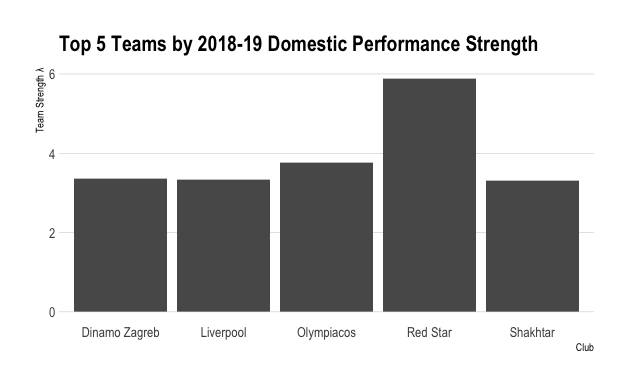

## Fitting Bradley-Terry Model based on Domestic League + UCL Group Stage and Round of 16 results

```
uefa = remove_xg(uefa)
```

```
uefa = read_csv('../data/raw/UEFA_Champions_League_2020_Results_RAW.csv')

uefa_playoff_teams = c(
  "Atalanta", "RB Leipzig", "Barcelona", "Manchester City",
  "Lyon", "Paris S-G", "Atlético Madrid", "Bayern Munich"
)

uefa_playoff_teams
```

```
[1] "Atalanta"        "RB Leipzig"      "Barcelona"       "Manchester City" "Lyon"            "Paris S-G"       "Atlético Madrid" "Bayern Munich"
```

```
uefa_group_ro16 = uefa %>% filter(Round %in% c("Group stage", "Round of 16"))

uefa_group_ro16
```

| Competition_Name | Gender | Country | Season_End_Year | Round | Wk | Day | Date | Time | Home | HomeGoals | Home_xG | Away | AwayGoals | Away_xG | Attendance | Venue | Referee | Notes | MatchURL |
| --- | --- | --- | --- | --- | --- | --- | --- | --- | --- | --- | --- | --- | --- | --- | --- | --- | --- | --- | --- |
| UEFA Champions League | M | NA | 2020 | Group stage | 1 | Tue | 2019-09-17 | 18:55:00 | Lyon fr | 1 | 1.6 | ru Zenit | 1 | 1.0 | 47201 | Groupama Stadium | Michael Oliver | NA | https://fbref.com/en/matches/7f6a5ede/Lyon-Zenit-September-17-2019-Champions-League |
| UEFA Champions League | M | NA | 2020 | Group stage | 1 | Tue | 2019-09-17 | 18:55:00 | Inter it | 1 | 1.4 | cz Slavia Prague | 1 | 1.0 | 50128 | Stadio Giuseppe Meazza | Ruddy Buquet | NA | https://fbref.com/en/matches/b56e2c3b/Internazionale-Slavia-Prague-September-17-2019-Champions-League |
| UEFA Champions League | M | NA | 2020 | Group stage | 1 | Tue | 2019-09-17 | 20:00:00 | Benfica pt | 1 | 1.8 | de RB Leipzig | 2 | 1.0 | 46460 | Estádio do Sport Lisboa e Benfica | Tasos Sidiropoulos | NA | https://fbref.com/en/matches/f871df3b/Benfica-RB-Leipzig-September-17-2019-Champions-League |
| UEFA Champions League | M | NA | 2020 | Group stage | 1 | Tue | 2019-09-17 | 20:00:00 | Chelsea eng | 0 | 2.8 | es Valencia | 1 | 1.0 | 39469 | Stamford Bridge | Cüneyt Çakιr | NA | https://fbref.com/en/matches/8c3140a0/Chelsea-Valencia-September-17-2019-Champions-League |
| UEFA Champions League | M | NA | 2020 | Group stage | 1 | Tue | 2019-09-17 | 21:00:00 | RB Salzburg at | 6 | 4.3 | be Genk | 2 | 0.7 | 29520 | Red Bull Arena | Felix Zwayer | NA | https://fbref.com/en/matches/5b62cee4/Red-Bull-Salzburg-Genk-September-17-2019-Champions-League |
| UEFA Champions League | M | NA | 2020 | Group stage | 1 | Tue | 2019-09-17 | 21:00:00 | Ajax nl | 3 | 1.5 | fr Lille | 0 | 2.0 | 51441 | Johan Cruyff ArenA | Srđan Jovanović | NA | https://fbref.com/en/matches/602b7cb7/Ajax-Lille-September-17-2019-Champions-League |
| UEFA Champions League | M | NA | 2020 | Group stage | 1 | Tue | 2019-09-17 | 21:00:00 | Napoli it | 2 | 1.8 | eng Liverpool | 0 | 0.7 | 38878 | Stadio San Paolo | Felix Brych | NA | https://fbref.com/en/matches/83579d2e/Napoli-Liverpool-September-17-2019-Champions-League |
| UEFA Champions League | M | NA | 2020 | Group stage | 1 | Tue | 2019-09-17 | 21:00:00 | Dortmund de | 0 | 3.4 | es Barcelona | 0 | 0.4 | 66099 | Signal Iduna Park | Ovidiu Hațegan | NA | https://fbref.com/en/matches/15996455/Dortmund-Barcelona-September-17-2019-Champions-League |
| UEFA Champions League | M | NA | 2020 | Group stage | 1 | Wed | 2019-09-18 | 18:55:00 | Club Brugge be | 0 | 1.7 | tr Galatasaray | 0 | 0.6 | 26616 | Jan Breydelstadion | Slavko Vinčič | NA | https://fbref.com/en/matches/7b5b1e42/Club-Brugge-Galatasaray-September-18-2019-Champions-League |
| UEFA Champions League | M | NA | 2020 | Group stage | 1 | Wed | 2019-09-18 | 19:55:00 | Olympiacos gr | 2 | 1.7 | eng Tottenham | 2 | 1.7 | 31001 | Stadio Georgios Karaiskáki | Gianluca Rocchi | NA | https://fbref.com/en/matches/a6045d6f/Olympiacos-Tottenham-Hotspur-September-18-2019-Champions-League |

[output cut: 102 more lines]

```
z = colnames(uefa)
z = z[colnames(uefa) %in% colnames(all)]
uefa = uefa %>% select(z)
all_combined = all %>% rbind(uefa)


head(all_combined)
```

| Competition_Name | Gender | Country | Season_End_Year | Round | Wk | Day | Date | Time | Home | HomeGoals | Away | AwayGoals | Attendance | Venue | Referee | Notes | MatchURL |
| --- | --- | --- | --- | --- | --- | --- | --- | --- | --- | --- | --- | --- | --- | --- | --- | --- | --- |
| Austrian Football Bundesliga | M | AUT | 2019 | Regular season | 1 | Fri | 2018-07-27 | 20:45:00 | Austria Wien | 2 | Wacker Innsbr | 1 | 12673 | Generali Arena | Christopher Jäger | NA | https://fbref.com/en/matches/6c36d5e8/Austria-Wien-Wacker-Innsbruck-July-27-2018-Austrian-Bundesliga |
| Austrian Football Bundesliga | M | AUT | 2019 | Regular season | 1 | Sat | 2018-07-28 | 17:00:00 | SCR Altach | 2 | Mattersburg | 3 | 4523 | CASHPOINT Arena | Dieter Muckenhammer | NA | https://fbref.com/en/matches/b5940ee5/Rheindorf-Altach-Mattersburg-July-28-2018-Austrian-Bundesliga |
| Austrian Football Bundesliga | M | AUT | 2019 | Regular season | 1 | Sat | 2018-07-28 | 17:00:00 | Sturm Graz | 3 | Hartberg | 2 | 10785 | Merkur Arena | Rene Eisner | NA | https://fbref.com/en/matches/f54b7835/Sturm-Graz-Hartberg-July-28-2018-Austrian-Bundesliga |
| Austrian Football Bundesliga | M | AUT | 2019 | Regular season | 1 | Sun | 2018-07-29 | 17:00:00 | St. Pölten | 4 | Wolfsberger AC | 3 | 2786 | NV Arena | Robert Schörgenhofer | NA | https://fbref.com/en/matches/44323758/St-Polten-Wolfsberger-AC-July-29-2018-Austrian-Bundesliga |
| Austrian Football Bundesliga | M | AUT | 2019 | Regular season | 1 | Sun | 2018-07-29 | 17:00:00 | Admira | 0 | Rapid Wien | 3 | 5200 | BSFZ-Arena | Alexander Harkam | NA | https://fbref.com/en/matches/9b206c50/Admira-Wacker-Modling-Rapid-Wien-July-29-2018-Austrian-Bundesliga |
| Austrian Football Bundesliga | M | AUT | 2019 | Regular season | 1 | Sun | 2018-07-29 | 17:00:00 | RB Salzburg | 3 | LASK | 1 | 11532 | Red Bull Arena | Harald Lechner | NA | https://fbref.com/en/matches/7704f43d/Red-Bull-Salzburg-LASK-July-29-2018-Austrian-Bundesliga |

```
no_ties_combined = all_combined %>%
  filter(HomeGoals != AwayGoals) %>%
  mutate(Home_Winner = as.numeric(HomeGoals > AwayGoals),
         Opp_Winner  = as.numeric(AwayGoals > HomeGoals))

unik_teams = sort(unique(c(no_ties_combined$Home, no_ties_combined$Away)))

results_combined = no_ties_combined %>%
  rename(home.team = Home, away.team = Away) %>%
  group_by(home.team, away.team) %>%
  summarise(
    home.win = sum(Home_Winner),
    away.win = sum(Opp_Winner),
    .groups = "drop"
  ) %>%
  mutate(
    home.team = factor(home.team, levels = unik_teams),
    away.team = factor(away.team, levels = unik_teams)
  )


fit_all = BTm(
  outcome = cbind(home.win, away.win),
  player1 = home.team,
  player2 = away.team,
  refcat = "Yenisey",
  data = results_combined
)
```

```
combined_lambda_hat = as.data.frame(BradleyTerry2::BTabilities(fit_all)) %>%
  rownames_to_column("team") %>%
  arrange(desc(ability))

combined_lambda_hat
```

| team | ability | s.e. |
| --- | --- | --- |
| Slavia Prague | 2.067900e+01 | 3.956180e+03 |
| Viktoria Plzeň | 2.049829e+01 | 3.956180e+03 |
| Sparta Prague | 1.952134e+01 | 3.956180e+03 |
| Jablonec | 1.914797e+01 | 3.956180e+03 |
| PAOK | 1.886543e+01 | 6.693690e+02 |
| Mladá Boleslav | 1.886308e+01 | 3.956180e+03 |
| Baník Ostrava | 1.863311e+01 | 3.956180e+03 |
| Slovan Liberec | 1.850539e+01 | 3.956180e+03 |
| Sigma Olomouc | 1.844173e+01 | 3.956180e+03 |
| Fastav Zlín | 1.841409e+01 | 3.956180e+03 |

[output cut: 337 more lines]

```
NA
```

```
plot = ggplot2::ggplot(combined_lambda_hat %>% arrange(desc(ability)) %>% head(5), aes(reorder(team, -ability), ability)) +
  ggplot2::geom_col() +
  labs(title = "Top 5 Teams by UCL 2019-2020 Group Stage + RO16 Performance Strength", x = "Club", y = "Team Strength λ")
plot
```

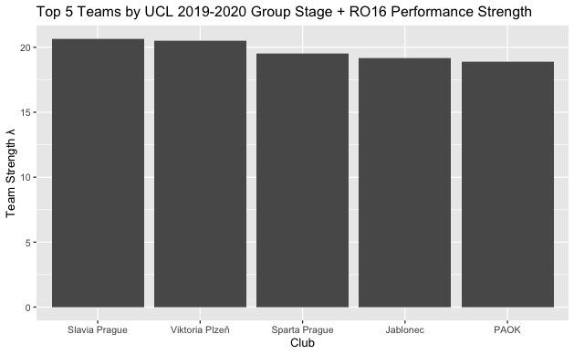

```
uefa_playoff_teams= c(
  "Atalanta", "RB Leipzig", "Barcelona", "Manchester City",
  "Lyon", "Paris S-G", "Atlético Madrid", "Bayern Munich"
)

combined_lambda_hat = combined_lambda_hat %>%
  filter(team %in% uefa_playoff_teams)

combined_lambda_hat %>% arrange(desc(ability))
```

| team | ability | s.e. |
| --- | --- | --- |
| Paris S-G | 2.5871996 | 0.6797405 |
| Barcelona | 2.5401725 | 0.7525521 |
| Manchester City | 2.0782767 | 0.7119963 |
| Lyon | 1.7296549 | 0.6404800 |
| Atlético Madrid | 1.6782414 | 0.6414430 |
| Bayern Munich | 1.6620514 | 0.7153158 |
| Atalanta | 1.0936900 | 0.5903573 |
| RB Leipzig | 0.9345248 | 0.6670111 |

```
strength_plot = combined_lambda_hat %>%
  arrange(desc(ability)) %>%
  ggplot(aes(x = reorder(team, ability), y = ability)) +
  geom_col(fill = "#1f78b4", width = 0.7) +
  geom_text(aes(label = round(ability, 2)),
            hjust = -0.1, size = 4, color = "black") +
  coord_flip(clip = "off") +
  scale_y_continuous(
    expand = expansion(mult = c(0, 0.1))
  ) +
  labs(
    title = "Playoff Teams Strengths",
    subtitle = "Bradley–Terry Model Estimated Team Abilities (λ)",
    x = "Team",
    y = "Ability (λ)"
  ) +
  theme_minimal(base_size = 13) +
  theme(
    plot.title = element_text(face = "bold"),
    plot.subtitle = element_text(size = 11, color = "gray30"),
    axis.text.y = element_text(face = "bold"),
    axis.title.y = element_text(vjust = 1),
    panel.grid.major.y = element_blank(),
    panel.grid.minor = element_blank(),
    plot.margin = margin(10, 40, 10, 10)
  )
strength_plot
```

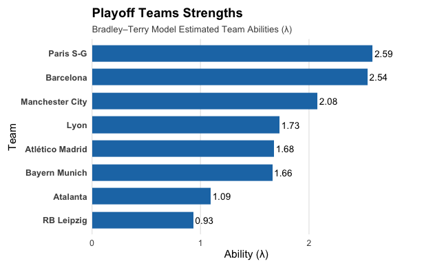

```
avg_goals = uefa %>%
  filter(Round %in% c("Group stage", "Round of 16")) %>%
  mutate(total_goals = HomeGoals + AwayGoals) %>%
  summarise(avg_goals = mean(total_goals, na.rm = TRUE))

avg_goals
```

| avg_goals |
| --- |
| 3.205357 |

```
quarters = data.frame(
  Hi = c("Atalanta", "RB Leipzig", "Barcelona", "Manchester City"),
  Lo = c("Paris S-G", "Atlético Madrid", "Bayern Munich", "Lyon"),
  stringsAsFactors = FALSE
)

quarters
```

| Hi | Lo |
| --- | --- |
| Atalanta | Paris S-G |
| RB Leipzig | Atlético Madrid |
| Barcelona | Bayern Munich |
| Manchester City | Lyon |

```
NA
```

##### Two-legged quarter-finals and semi-finals simulation

In the 19/20 UCL season, the quarter-finals and semi-finals were changed from being 2 legged to just a one leg match. We will simulate the quarter-finals and semi-finals as if it were 2-legged by using the aggregate goals to decide the winner over the two legs. To simulate how many goals a team would score, we use the team’s ability based on the Bradley-Terry model and the average goal scored over the UCL Group Stage and Round of 16

```
# compute win probabilities
possible_matchups = quarters %>%
  dplyr::left_join(combined_lambda_hat %>% dplyr::select(team, ability),
                   by = c("Hi" = "team")) %>%
  dplyr::rename(Hi_ability = ability) %>%
  dplyr::left_join(combined_lambda_hat %>% dplyr::select(team, ability),
                   by = c("Lo" = "team")) %>%
  dplyr::rename(Lo_ability = ability) %>%
  dplyr::mutate(
    # expected goal rate scaling based on relative Bradley-Terry abilities
    Hi_lambda = exp(Hi_ability) / (exp(Hi_ability) + exp(Lo_ability)) * 3.205357,
    Lo_lambda = exp(Lo_ability) / (exp(Hi_ability) + exp(Lo_ability)) * 3.205357
  )

# Helper function for 2-leg tie using aggregate goals
simulate_two_leg_goals = function(ability_hi, ability_lo, avg_goals = 3.205357) {
  # Convert BT abilities into expected goal rates per match
  lambda_hi = exp(ability_hi) / (exp(ability_hi) + exp(ability_lo)) * avg_goals
  lambda_lo = exp(ability_lo) / (exp(ability_hi) + exp(ability_lo)) * avg_goals

  # Simulate goals for each of the two legs
  # Each team plays two matches, goals ~ Poisson distributed
  leg1_hi = rpois(1, lambda_hi)
  leg1_lo = rpois(1, lambda_lo)
  leg2_hi = rpois(1, lambda_hi)
  leg2_lo = rpois(1, lambda_lo)

  # Aggregate total goals across both legs
  total_hi = leg1_hi + leg2_hi
  total_lo = leg1_lo + leg2_lo

  # Decide winner based on aggregate goals
  if (total_hi > total_lo) {
    return(1)  # Hi team advances
  } else if (total_lo > total_hi) {
    return(0)  # Lo team advances
  } else {
    # Tie after two legs
    # Compute win probability based on relative abilities
    prob_hi_wins_tiebreak = exp(ability_hi) / (exp(ability_hi) + exp(ability_lo))
    return(rbinom(1, 1, prob_hi_wins_tiebreak))  # weighted shootout
  }
}

possible_matchups
```

| Hi | Lo | Hi_ability | Lo_ability | Hi_lambda | Lo_lambda |
| --- | --- | --- | --- | --- | --- |
| Atalanta | Paris S-G | 1.0936900 | 2.587200 | 0.5878482 | 2.6175088 |
| RB Leipzig | Atlético Madrid | 0.9345248 | 1.678241 | 1.0327403 | 2.1726167 |
| Barcelona | Bayern Munich | 2.5401725 | 1.662051 | 2.2643691 | 0.9409879 |
| Manchester City | Lyon | 2.0782767 | 1.729655 | 1.8792474 | 1.3261096 |

```
n_sims = 10000

alt_results = data.frame(
  QF_Match1 = rep(NA, n_sims),
  QF_Match2 = rep(NA, n_sims),
  QF_Match3 = rep(NA, n_sims),
  QF_Match4 = rep(NA, n_sims),
  QF_Winner1 = rep(NA, n_sims),
  QF_Winner2 = rep(NA, n_sims),
  QF_Winner3 = rep(NA, n_sims),
  QF_Winner4 = rep(NA, n_sims),
  SF_Match1 = rep(NA, n_sims),
  SF_Match2 = rep(NA, n_sims),
  SF1_Winner = rep(NA, n_sims),
  SF2_Winner = rep(NA, n_sims),
  Finals_Hi = rep(NA, n_sims),
  Finals_Lo = rep(NA, n_sims),
  Champion = rep(NA, n_sims)
)

for (r in 1:n_sims) {
  set.seed(321 + r)

  # qf
  qf_winners = rep(NA, nrow(possible_matchups))

  for (i in 1:nrow(possible_matchups)) {
    result = simulate_two_leg_goals(
      ability_hi = possible_matchups$Hi_ability[i],
      ability_lo = possible_matchups$Lo_ability[i],
      avg_goals = 3.205357
    )
    qf_winners[i] = ifelse(result == 1, possible_matchups$Hi[i], possible_matchups$Lo[i])

    # store QF matchups
    alt_results[r, paste0("QF_Match", i)] =
      paste(possible_matchups$Hi[i], "vs", possible_matchups$Lo[i])
    alt_results[r, paste0("QF_Winner", i)] = qf_winners[i]
  }

```

[output cut: 50 more lines]

```
  alt_results[r, "Finals_Hi"] = finals$Hi[1]
  alt_results[r, "Finals_Lo"] = finals$Lo[1]

  # simulate one-leg final
  final_outcome = rbinom(1, 1, finals$prob[1])
  alt_results[r, "Champion"] =
    ifelse(final_outcome == 1, finals$Hi[1], finals$Lo[1])
}

# results
champions = alt_results %>%
  dplyr::count(Champion, sort = TRUE) %>%
  dplyr::mutate(Prob = n / n_sims)

champions
```

| Champion | n | Prob |
| --- | --- | --- |
| Paris S-G | 4862 | 0.4862 |
| Barcelona | 3468 | 0.3468 |
| Manchester City | 827 | 0.0827 |
| Atlético Madrid | 451 | 0.0451 |
| Lyon | 206 | 0.0206 |
| Bayern Munich | 147 | 0.0147 |
| Atalanta | 24 | 0.0024 |
| RB Leipzig | 15 | 0.0015 |

```
NA
```

```
champions_plot = champions %>%
  ggplot(aes(x = reorder(Champion, Prob), y = Prob)) +
  geom_col(fill = "#1f78b4") +
  geom_text(aes(label = scales::percent(Prob, accuracy = 0.1)),
            hjust = -0.1, size = 4) +
  coord_flip(clip = "off") +
  scale_y_continuous(labels = scales::percent_format(accuracy = 1), limits = c(0, max(champions$Prob) * 1.15)) +
  labs(
    title = "Simulated Champions (10,000 Runs)",
    subtitle = "2019–20 UEFA Champions League (BT + Poisson Model)",
    x = "Team",
    y = "Probability of Winning"
  ) +
  theme_minimal(base_size = 13) +
  theme(
    plot.title = element_text(face = "bold"),
    axis.title.y = element_text(vjust = 1),
    axis.text.y = element_text(face = "bold"),
    plot.margin = margin(10, 40, 10, 10)
  )

champions_plot
```

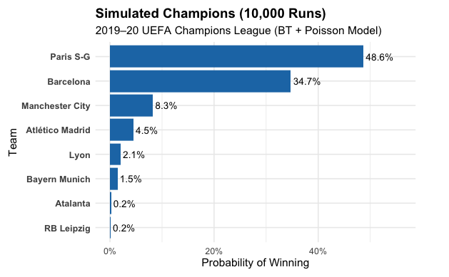

```
sf_matchups = alt_results %>%
  select(SF_Match1, SF_Match2) %>%
  pivot_longer(cols = everything(), values_to = "Matchup") %>%
  count(Matchup, sort = TRUE) %>%
  mutate(Prob = n / n_sims)

sf_plot = sf_matchups %>%
  ggplot(aes(x = reorder(Matchup, Prob), y = Prob)) +
  geom_col(fill = "#1f78b4") +
  geom_text(
    aes(label = scales::percent(Prob, accuracy = 0.1)),
    hjust = -0.1, size = 4
  ) +
  coord_flip(clip = "off") +
  scale_y_continuous(
    labels = scales::percent_format(accuracy = 1),
    limits = c(0, max(sf_matchups$Prob) * 1.15)
  ) +
  labs(
    title = "Most Common Semifinal Matchups (10,000 Runs)",
    subtitle = "2019–20 UEFA Champions League Simulation (Bradley–Terry + Poisson)",
    x = "Semifinal Matchup",
    y = "Probability"
  ) +
  theme_minimal(base_size = 13) +
  theme(
    plot.title = element_text(face = "bold"),
    axis.title.y = element_text(vjust = 1),
    axis.text.y = element_text(face = "bold"),
    plot.margin = margin(10, 40, 10, 10)
  )
sf_plot
```

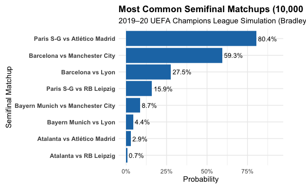

```
final_matchups = alt_results %>%
  mutate(
    Final_Pair = paste(
      pmin(Finals_Hi, Finals_Lo),
      pmax(Finals_Hi, Finals_Lo),
      sep = " vs "
    )
  ) %>%
  count(Final_Pair, sort = TRUE) %>%
  mutate(Prob = n / n_sims)

final_plot = final_matchups %>%
  ggplot(aes(x = reorder(Final_Pair, Prob), y = Prob)) +
  geom_col(fill = "#e31a1c") +
  geom_text(
    aes(label = scales::percent(Prob, accuracy = 0.1)),
    hjust = -0.1, size = 4
  ) +
  coord_flip(clip = "off") +
  scale_y_continuous(
    labels = scales::percent_format(accuracy = 1),
    limits = c(0, max(final_matchups$Prob) * 1.15)
  ) +
  labs(
    title = "Most Common Final Matchups (10,000 Runs)",
    subtitle = "2019–20 UEFA Champions League Simulation (Bradley–Terry + Poisson)",
    x = "Final Matchup",
    y = "Probability"
  ) +
  theme_minimal(base_size = 13) +
  theme(
    plot.title = element_text(face = "bold"),
    axis.title.y = element_text(vjust = 1),
    axis.text.y = element_text(face = "bold"),
    plot.margin = margin(10, 40, 10, 10)
  )
final_plot
```

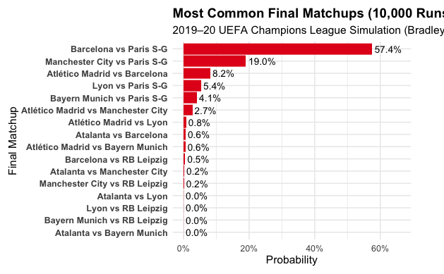

## Fitting Bradley-Terry with Domestic Strength Covariate

Now, we’ll begin by normalizing our derived domestic strengths for each team so that our model can better fit coefficients to the data, and prepare a data frame such that our Bradley-Terry model can be fit using these domestic strengths. Ideally, we’ll use these strengths to define the probability,
$$\mathbb{P}(\text{team i with domestic strength x beats team j with
domestic strength y}) =
\frac{1}{1+e^{-1\times(((\lambda_i+x\lambda_0))-(\lambda_j+y\lambda_0))}}$$

```
# Normalize strengths
domestic_strength$ability = (domestic_strength$ability-mean(domestic_strength$ability))/sqrt(var(domestic_strength$ability))
domestic_strength
```

| Home | Country | ability | s.e. |
| --- | --- | --- | --- |
| Slavia Prague | cz | 4.97546399 | 1455.3977126 |
| Red Star | rs | 1.03535266 | 1.3746661 |
| Olympiacos | gr | 0.98150692 | 1.2855556 |
| Dinamo Zagreb | hr | 0.26114801 | 0.9317167 |
| Liverpool | eng | 0.25277009 | 1.1183687 |
| Shakhtar | ua | 0.24719948 | 1.1540573 |
| Benfica | pt | 0.19363809 | 0.8328164 |
| Paris S-G | fr | 0.02521987 | 0.6797405 |
| Ajax | nl | 0.01466159 | 0.7061374 |
| Barcelona | es | 0.01075315 | 0.7525521 |

[output cut: 22 more lines]

With our strengths now together, we’ll do an initial fit of the Bradley-Terry model, and use the coefficient of `domestic.strength` for $\lambda_0$.

```
suppressWarnings({
  fit <-
  BradleyTerry2::BTm(
    outcome = cbind(home.win, away.win),
    player1 = home.team, player2 = away.team,
    formula = ~ team + domestic.strength,
    refcat = "Dinamo Zagreb",
    id = "team",
    separate.ability = TRUE,
    data = tmp)
})
coef(fit)
```

```
           teamAjax        teamAtalanta teamAtlético Madrid       teamBarcelona   teamBayern Munich         teamBenfica         teamChelsea
         1.91093230         -4.10757784          4.95066600         18.32958833         22.28206432          5.44814350         -0.44969513
    teamClub Brugge        teamDortmund     teamGalatasaray            teamGenk           teamInter        teamJuventus      teamLeverkusen
       -18.70819436         -4.38467893        -19.85040829        -20.23717119         -5.05859911         26.93327005          1.53171789
          teamLille       teamLiverpool     teamLoko Moscow            teamLyon teamManchester City          teamNapoli      teamOlympiacos
       -20.53087530         22.57980919                  NA          3.26622059         19.68974470         38.90603915        -11.15999392
      teamParis S-G      teamRB Leipzig     teamRB Salzburg     teamReal Madrid        teamRed Star        teamShakhtar   teamSlavia Prague
        22.23026883          2.93535866                  NA                  NA        -10.84192473         -0.08239455                  NA
      teamTottenham        teamValencia           teamZenit   domestic.strength
                 NA                  NA                  NA         -5.26800595
```

Above, we see a significant issue: team strengths with the value `NA`. This likely arises due to the “disconnected” nature of the group stage data, or the nature that teams do not play other teams outside of their group. Therefore, to determine a strength for each team, we’ll take a sample of reference teams, fit the Bradley-Terry model to each, and take the mean of each team’s strength.

```
run_mult_fits = function(num_fits, with_replacement = FALSE, full=FALSE){
  set.seed(439)
  champs = read_csv('../data/raw/UEFA_Champions_League_2020_Results_RAW.csv', show_col_types=FALSE)
  no_ties = champs %>%
    select(-c('Competition_Name','Gender','Country', 'Season_End_Year', 'Wk', 'Date', 'Day','Time', 'Home_xG', 'Away_xG', 'Attendance', 'Referee', 'Notes','Venue', 'MatchURL')) %>%
    filter(HomeGoals != AwayGoals & Round == 'Group stage') %>%
    select(-c('Round')) %>%
    mutate(Home = str_replace(Home, ' [a-z]{2,3}$', ''),
           Away = str_replace(Away, '^[a-z]{2,3} ', ''),
           Home_Winner = case_when(HomeGoals > AwayGoals ~ 1, .default=0),
           Opp_Winner = case_when(AwayGoals > HomeGoals ~ 1, .default=0))
  unik_teams = sort(unique(c(no_ties$Home, no_ties$Away)))
  suppressWarnings({
    fit <-
    BradleyTerry2::BTm(
      outcome = cbind(home.win, away.win),
      player1 = home.team, player2 = away.team,
      formula = ~ team + domestic.strength,
      refcat = 'Ajax',
      id = "team",
      separate.ability = TRUE,
      data = tmp)
  })
  coefs = transpose(data.table(unik_teams))
  colnames(coefs) = coef(fit) %>% names
  coefs[1,] = 0
  for(i in 2:num_fits){
    zero_row = transpose(data.table(rep(0,length(colnames(coefs)))))
    colnames(zero_row) = coef(fit) %>% names
    coefs = coefs %>% rbind(zero_row)
  }
  coefs$Ref = sample(unik_teams,size=num_fits,replace=with_replacement)

  c = transpose(data.frame(coef(fit)))
  colnames(c) = coef(fit) %>% names
  coefs = coefs %>% select(c(colnames(c), str_c(),'Ref')) %>% select(-c('domestic.strength'))
  ref_cat = str_c('team',coefs[1,] %>% pull(Ref))
  c[1,'Ref'] = coefs[1,] %>% pull(Ref)
  coefs[1,] = c[1,] %>% select(-c('domestic.strength'))
  coefs[1,ref_cat] = 0
```

[output cut: 24 more lines]

```
  coefs[is.na(coefs)] = 0
  teams = coefs %>% select(-c('Ref')) %>% names
  adjusted_coefs = c()
  for(i in 1:length(teams)){
    team = as.numeric(coefs %>% pull(teams[i]))
    team = team[team != 0]
    adjusted_coef = sum(team)/length(team)
    adjusted_coefs[length(adjusted_coefs) + 1] = adjusted_coef
  }
  adjusted = tibble(team = teams %>% str_replace('team', ''), ability = adjusted_coefs)
  if(full){
    return(list(coefs, adjusted))
  }
  return(adjusted)
}
```

```
lambda0_hat = -5.26800595 # from initial fit
lambda_hat = run_mult_fits(100, with_replacement=TRUE)
sd_ability = sd(c(lambda_hat$ability, lambda0_hat))
mu_ability = mean(c(lambda_hat$ability, lambda0_hat))

## normalizing results
lambda0_hat = (-5.26800595-mu_ability)/sd_ability
lambda_hat$ability = (lambda_hat$ability-mu_ability)/sd_ability

uefa_playoff_teams= c(
  "Atalanta", "RB Leipzig", "Barcelona", "Manchester City",
  "Lyon", "Paris S-G", "Atlético Madrid", "Bayern Munich"
)
uefa_playoff_team_strengths = lambda_hat[lambda_hat$team %in% uefa_playoff_teams,] %>% column_to_rownames('team')
uefa_playoff_team_strengths %>% arrange(desc(ability))
```

|  | ability |
| --- | --- |
| Paris S-G | 1.4467419 |
| Bayern Munich | 1.4019749 |
| Manchester City | 1.2364318 |
| Barcelona | 1.1535283 |
| Atlético Madrid | 0.2808478 |
| Lyon | 0.1548366 |
| RB Leipzig | 0.1331489 |
| Atalanta | -0.3362733 |

With our team strengths in place, we can now begin computing the probabilities for each potential match-up that occurs in the quarter final through the final round, based on the formula described above.

| team1 | team2 | team1_strength | team2_strength | team1_domestic | team2_domestic | prob |
| --- | --- | --- | --- | --- | --- | --- |
| Atlético Madrid | Atalanta | 0.2808478 | -0.3362733 | -0.25439855 | -0.43422128 | 0.6346798 |
| Barcelona | Atalanta | 1.1535283 | -0.3362733 | 0.01075315 | -0.43422128 | 0.7907604 |
| Bayern Munich | Atalanta | 1.4019749 | -0.3362733 | -0.25937901 | -0.43422128 | 0.8422768 |
| Lyon | Atalanta | 0.1548366 | -0.3362733 | -0.23858245 | -0.43422128 | 0.6036359 |
| Manchester City | Atalanta | 1.2364318 | -0.3362733 | -0.13133762 | -0.43422128 | 0.8120829 |
| Paris S-G | Atalanta | 1.4467419 | -0.3362733 | 0.02521987 | -0.43422128 | 0.8344525 |
| RB Leipzig | Atalanta | 0.1331489 | -0.3362733 | -0.48318449 | -0.43422128 | 0.6194135 |
| Atalanta | Atlético Madrid | -0.3362733 | 0.2808478 | -0.43422128 | -0.25439855 | 0.3653202 |
| Barcelona | Atlético Madrid | 1.1535283 | 0.2808478 | 0.01075315 | -0.25439855 | 0.6850696 |
| Bayern Munich | Atlético Madrid | 1.4019749 | 0.2808478 | -0.25937901 | -0.25439855 | 0.7545301 |

[output cut: 46 more lines]

| Home | HomeGoals | Away | AwayGoals |
| --- | --- | --- | --- |
| Lyon | 1 | Zenit | 1 |
| Inter | 1 | Slavia Prague | 1 |
| Benfica | 1 | RB Leipzig | 2 |
| Chelsea | 0 | Valencia | 1 |
| RB Salzburg | 6 | Genk | 2 |
| Ajax | 3 | Lille | 0 |
| Napoli | 2 | Liverpool | 0 |
| Dortmund | 0 | Barcelona | 0 |
| Club Brugge | 0 | Galatasaray | 0 |
| Olympiacos | 2 | Tottenham | 2 |

[output cut: 86 more lines]

Since each round but the final takes place over two games, the chance of seeing the teams split the two games is high. Therefore, we need a way to choose a winner based on some other source of information. Thankfully, we have access to goal scoring data from the group stage, which we can use to make an informed estimation of the tie-breaking criteria that is used in this case in the actual UCL tournament: goal aggregate. For this, we’ll take the mean of the goals scored for each team throughout the group stage and use it as the parameter for a Poisson distribution. Poisson distributions have long been used for simulating goals scored for a particular team, often utilizing the same methodology to choose the value of $\lambda$ (Heuer and et al. 2010).

In other words, in the event of a tie between the two legs, we’ll choose a goal value based on the following distribution:
$$\lambda_i = \text{mean goals for team i in
group stage}; \text{Draw from Pois}(\lambda_i)=\text{team i
goals}$$

The helper function below will run a single iteration of our simulation:

```
run_iteration = function(seed=439, verbose=FALSE){
  knockout = tibble(round = c(rep('Quarter', 4), c(rep('Semi', 2)), 'Final'), team1 = rep('',7), team2 = rep('',7), winner = rep('',7))
  knockout[1,'team1'] = 'RB Leipzig'
  knockout[1,'team2'] = 'Atlético Madrid'

  knockout[2,'team1'] = 'Atalanta'
  knockout[2,'team2'] = 'Paris S-G'

  knockout[3,'team1'] = 'Manchester City'
  knockout[3,'team2'] = 'Lyon'

  knockout[4,'team1'] = 'Barcelona'
  knockout[4,'team2'] = 'Bayern Munich'
  set.seed(seed)
  quarters = c()
  for(i in 1:4){
    team_a = knockout[i,] %>% pull('team1')
    team_b = knockout[i,] %>% pull('team2')
    prob_team1 = possible_matchups %>% filter(team1 == team_a & team2 == team_b) %>% pull('prob')
    if(verbose){
      print(str_c("Quarter ",i," Probability that team 1 ", team_a, " beats team 2 ", team_b, " :", prob_team1))
    }
    results = rbinom(n=2, size=1, prob=prob_team1)
    if(results[1] != results[2]){
      if(verbose){
        print(str_c(team_a, " and ", team_b, " split series. Using tie breaker..."))
      }
      mean_team1 = group_stage %>% filter(Home == team_a | Away == team_a) %>%
        mutate(TotGoals = case_when(Home == team_a ~ HomeGoals, Away == team_a ~ AwayGoals)) %>%
        select(TotGoals) %>% pull(TotGoals) %>% as.numeric() %>%
        mean()

      mean_team2 = group_stage %>% filter(Home == team_b | Away == team_b) %>%
        mutate(TotGoals = case_when(Home == team_b ~ HomeGoals, Away == team_b ~ AwayGoals)) %>%
        select(TotGoals) %>% pull(TotGoals) %>%
        as.numeric() %>%
        mean()

      ## choose winner
      team1_goals = rpois(1, mean_team1)
```

[output cut: 82 more lines]

```
  if(verbose){
    print(str_c("Final: Probability that team 1 ", team_a, " beats team 2 ", team_b, " :", prob_team1))
  }
  result = rbinom(n=1, size=1, prob=prob_team1)
  if(result == 1){
    winner = team_a
  } else {
    winner = team_b
  }
  if(verbose){
    print(str_c(winner, " WINS"))
  }
  knockout[7,'winner'] = winner
  return(knockout)
}
```

We’ll run one simulation to get an idea of how the results are structured and use the `verbose` option to get a read of the simulation’s stages.

```
# Example of simulation when run verbose
run_iteration(verbose=TRUE)
```

```
[1] "Quarter 1 Probability that team 1 RB Leipzig beats team 2 Atlético Madrid :0.483684134254207"
[1] "Quarter 2 Probability that team 1 Atalanta beats team 2 Paris S-G :0.165547545542045"
[1] "Atalanta and Paris S-G split series. Using tie breaker..."
[1] "Atalanta scored 1"
[1] "Paris S-G scored 6"
[1] "Quarter 3 Probability that team 1 Manchester City beats team 2 Lyon :0.739421494641044"
[1] "Manchester City and Lyon split series. Using tie breaker..."
[1] "Manchester City scored 3"
[1] "Lyon scored 2"
[1] "Quarter 4 Probability that team 1 Barcelona beats team 2 Bayern Munich :0.414412830117671"
[1] "Barcelona and Bayern Munich split series. Using tie breaker..."
[1] "Barcelona scored 2"
[1] "Bayern Munich scored 3"
[1] "Semi 1 Probability that team 1 RB Leipzig beats team 2 Paris S-G :0.244076636223594"
[1] "Semi 2 Probability that team 1 Manchester City beats team 2 Bayern Munich :0.447280277786489"
[1] "Final: Probability that team 1 Paris S-G beats team 2 Manchester City :0.538403123209533"
[1] "Paris S-G WINS"
```

| round | team1 | team2 | winner |
| --- | --- | --- | --- |
| Quarter | RB Leipzig | Atlético Madrid | RB Leipzig |
| Quarter | Atalanta | Paris S-G | Paris S-G |
| Quarter | Manchester City | Lyon | Manchester City |
| Quarter | Barcelona | Bayern Munich | Bayern Munich |
| Semi | RB Leipzig | Paris S-G | Paris S-G |
| Semi | Manchester City | Bayern Munich | Manchester City |
| Final | Paris S-G | Manchester City | Paris S-G |

| winner | n |
| --- | --- |
| Bayern Munich | 2 |
| Manchester City | 2 |
| Paris S-G | 6 |

```
# Medium-sized number of iterations
sims = run_n_iterations(1000, seed=12)
sims %>% filter(round == 'Final') %>% group_by(winner) %>% count()
```

| winner | n |
| --- | --- |
| Atalanta | 8 |
| Atlético Madrid | 28 |
| Barcelona | 43 |
| Bayern Munich | 314 |
| Lyon | 6 |
| Manchester City | 157 |
| Paris S-G | 418 |
| RB Leipzig | 26 |

After getting an idea of what type of results we should see, let’s run the simulation 10,000 times to get an idea of how we would expect the tournament to play out given our conditions.

```r
sims = run_n_iterations(10000)
```

| winner | n | prob |
| --- | --- | --- |
| Paris S-G | 4040 | 0.4040 |
| Bayern Munich | 3160 | 0.3160 |
| Manchester City | 1754 | 0.1754 |
| Barcelona | 451 | 0.0451 |
| Atlético Madrid | 243 | 0.0243 |
| RB Leipzig | 240 | 0.0240 |
| Lyon | 58 | 0.0058 |
| Atalanta | 54 | 0.0054 |

```
final_summary = sims %>% filter(round == 'Final') %>% group_by(team1, team2) %>% count() %>% arrange(desc(n))
final_summary %>% mutate(prob = n/sum(final_summary$n))
```

| team1 | team2 | n | prob |
| --- | --- | --- | --- |
| Paris S-G | Bayern Munich | 4311 | 0.4311 |
| Paris S-G | Manchester City | 2682 | 0.2682 |
| Paris S-G | Barcelona | 696 | 0.0696 |
| RB Leipzig | Bayern Munich | 545 | 0.0545 |
| Atlético Madrid | Bayern Munich | 433 | 0.0433 |
| RB Leipzig | Manchester City | 354 | 0.0354 |
| Atlético Madrid | Manchester City | 331 | 0.0331 |
| Paris S-G | Lyon | 169 | 0.0169 |
| Atalanta | Bayern Munich | 159 | 0.0159 |
| Atalanta | Manchester City | 85 | 0.0085 |

[output cut: 6 more lines]

From the two tables above, we see both results that align with the real outcome of the tournament (PSG vs. Bayern) along with results that diverge from history (PSG winning the tournament). Overall, although the predicted winner, PSG, didn’t win in real life, our results do roughly align with the match-ups and outcomes seen throughout the actual tournament. For instance, let’s view the most common semifinal matchups:

```
semi_summary = sims %>% filter(round == 'Semi') %>%
  group_by(team1, team2) %>%
  count() %>%
  arrange(desc(n))
semi_summary %>% mutate(prob = n/sum(semi_summary$n))
```

| team1 | team2 | n | prob |
| --- | --- | --- | --- |
| Manchester City | Bayern Munich | 6597 | 0.32985 |
| RB Leipzig | Paris S-G | 4911 | 0.24555 |
| Atlético Madrid | Paris S-G | 4297 | 0.21485 |
| Manchester City | Barcelona | 1817 | 0.09085 |
| Lyon | Bayern Munich | 1233 | 0.06165 |
| Atlético Madrid | Atalanta | 396 | 0.01980 |
| RB Leipzig | Atalanta | 396 | 0.01980 |
| Lyon | Barcelona | 353 | 0.01765 |

The top two results, Manchester City vs. Bayern Munich and RB Leipzig vs. PSG were the two actual semifinal match-ups in the 2019-2020 tournament.

## Integrating Home Field Advantage

We can refine the model above by also taking into account the advantage derived from playing at home throughout the group stage. From this, we’ll define the probability that team *i* beats team *j*, given team i and team j’s domestic strengths, and if team i is playing at home. This probability can be expressed as,
$$\mathbb{P}(\text{team i with domestic strength x beats team j with
domestic strength y at i's home}) =
\frac{1}{1+e^{-1\times(((\lambda_i+x\lambda_0)+\lambda_1)-(\lambda_j+y\lambda_0))}}$$

Thus, we’ll restructure our results data frame to work with the `BradleyTerry2` package with the domestic strengths we previously used and an indicator *at.home* for whether team i was at home or not.

```
unik_teams = sort(unique(c(no_ties$Home, no_ties$Away)))
results = no_ties %>%
  left_join(domestic_strength%>% select(Home, ability), relationship='many-to-many') %>%
  rename(home.domestic = ability) %>%
  left_join(domestic_strength %>% rename(Away = Home) %>% select(Away, ability), relationship='many-to-many') %>% rename(away.domestic = ability) %>%
  rename(home.team = Home, away.team = Away) %>%
    group_by(home.team, away.team) %>%
    dplyr::summarise(
        home.win = sum(Home_Winner),
        away.win = sum(Opp_Winner),
        home.domestic = mean(home.domestic),
        away.domestic = mean(away.domestic), .groups = 'drop') |>
    dplyr::mutate(
        home.team = factor(home.team, levels = unik_teams),
        away.team = factor(away.team, levels = unik_teams),
        home.athome = 1,
        away.athome = 0)
```

```
tmp = data.frame(home.win = results$home.win, away.win = results$away.win)
tmp$home.team = data.frame(
  team = results$home.team,
  domestic.strength = scale(results$home.domestic, center = TRUE, scale = TRUE)[,1],
  at.home = results$home.athome
)
tmp$away.team = data.frame(
  team = results$away.team,
  domestic.strength = scale(results$away.domestic, center = TRUE, scale = TRUE)[,1],
  at.home = results$away.athome
)
```

```
suppressWarnings({
  fit <-
  BradleyTerry2::BTm(
    outcome = cbind(home.win, away.win),
    player1 = home.team, player2 = away.team,
    formula = ~ team + domestic.strength + at.home,
    refcat = "Dinamo Zagreb",
    id = "team",
    separate.ability = TRUE,
    data = tmp)
})
coef(fit)
```

```
           teamAjax        teamAtalanta teamAtlético Madrid       teamBarcelona   teamBayern Munich         teamBenfica         teamChelsea
         1.80224040         -4.00115456          4.84067650         19.00311036         22.21687042          5.30166131         -0.46763475
    teamClub Brugge        teamDortmund     teamGalatasaray            teamGenk           teamInter        teamJuventus      teamLeverkusen
       -18.81109085         -3.67197734        -19.86996347        -20.26420270         -4.32843691         26.78053488          1.49181219
          teamLille       teamLiverpool     teamLoko Moscow            teamLyon teamManchester City          teamNapoli      teamOlympiacos
       -20.60994065         22.55145912                  NA          3.22317844         19.77098601         38.90278880        -11.42893700
      teamParis S-G      teamRB Leipzig     teamRB Salzburg     teamReal Madrid        teamRed Star        teamShakhtar   teamSlavia Prague
        22.09694106          2.88882052                  NA                  NA        -11.11910867         -0.08025979                  NA
      teamTottenham        teamValencia           teamZenit   domestic.strength             at.home
                 NA                  NA                  NA         -5.13151713          0.06547312
```

From the above, we see that the raw coefficient given to home pitch advantage is approximately 0.065. However, to remain consistent with the normalization standards we’ve used throughout this section, we’ll normalize this value given the mean and standard deviation of the previous coefficients.

```
lambda1_hat = (0.06547312-mu_ability)/sd_ability
lambda1_hat
```

```
[1] -0.02459572
```

However, after this normalization, our home advantage coefficient is negative, suggesting there is a disadvantage to playing at home. While this isn’t intuitive, given a history of literature in this area suggesting otherwise, it is possible that given this small sample, there was enough information to suggest this disadvantage. With that said, this is most likely due to the fact that we are normalizing this coefficient, which isn’t necessarily standard in this form of model fitting. Later, we’ll manually input a $\lambda$ for home advantage to determine if there is enough variation to indicate these results being faulty.

Because we are now factoring in home vs. away in this version of our simulation, we have to track who’s home during which leg. Throughout an actual tournament, in a two-leg round, each team plays one match at home. Thus, we’ve implemented this below, along with using the probability involving the normalized *at.home* coefficient.

Again, let’s start small, and get an idea of how our data will turn out.

| round_winner | n |
| --- | --- |
| Bayern Munich | 4 |
| Manchester City | 2 |
| Paris S-G | 3 |
| RB Leipzig | 1 |

As mentioned earlier, we want to be able to modify the $\lambda_1$ value manually. So, we’ll modify the helper to allow us to pass an argument to control this value.

```
run_n_iterations_w_home = function(n, lambda, seed=439){
  matchups =
  expand.grid(team1 = rownames(uefa_playoff_team_strengths), team2 = rownames(uefa_playoff_team_strengths)) %>%
  as.data.frame() %>%
  filter(team1 != team2) %>%
  dplyr::mutate(
    team1_strength = uefa_playoff_team_strengths[team1, "ability"], team2_strength = uefa_playoff_team_strengths[team2, "ability"])

  matchups = matchups %>%
    left_join(domestic_strength %>%
                rename(team1 = Home), by='team1') %>%
    select(-c('Country','s.e.')) %>%
    rename(team1_domestic = ability)
  matchups = matchups %>%
    left_join(domestic_strength %>%
                rename(team2 = Home),  by='team2') %>%
    select(-c('Country','s.e.')) %>%
    rename(team2_domestic = ability)

  matchups = matchups %>%
    rename(home = team1, away = team2) %>%
    mutate(
      prob = 1/(1+exp(-1*((team1_strength+(team1_domestic*lambda0_hat)+lambda)-(team2_strength+(team2_domestic*lambda0_hat)))))
    )
  n_iters = n
  sims = run_iteration_w_home(seed)
  for(i in 2:n_iters){
    sims = sims %>% rbind(run_iteration_w_home(seed=seed*i, proba=matchups))
  }
  return(sims)
}
```

Let’s compare the results of simulating the knockout stages past the round of 16 with both $\lambda_1*$, the normalized lambda for home pitch advantage, as well as the original computation for $\lambda_1=0.065$

*Results of using* $\lambda_1=-0.0245$

| round_winner | n |
| --- | --- |
| Paris S-G | 435 |
| Bayern Munich | 297 |
| Manchester City | 164 |
| Barcelona | 54 |
| Atlético Madrid | 23 |
| RB Leipzig | 19 |
| Lyon | 6 |
| Atalanta | 2 |

| round_winner | n |
| --- | --- |
| Paris S-G | 413 |
| Bayern Munich | 305 |
| Manchester City | 180 |
| Barcelona | 46 |
| RB Leipzig | 25 |
| Atlético Madrid | 15 |
| Lyon | 9 |
| Atalanta | 7 |

*Summary of tournament winners with 10,000 simulations and* $\lambda_1=0.06547312$

| round_winner | n | prob |
| --- | --- | --- |
| Paris S-G | 4039 | 0.4039 |
| Bayern Munich | 3125 | 0.3125 |
| Manchester City | 1818 | 0.1818 |
| Barcelona | 457 | 0.0457 |
| RB Leipzig | 254 | 0.0254 |
| Atlético Madrid | 193 | 0.0193 |
| Lyon | 59 | 0.0059 |
| Atalanta | 55 | 0.0055 |

*Summary of final round match-ups with 10,000 simulations and* $\lambda_1=0.06547312$

```
final_w_home_summary = sims %>% filter(round == 'Final') %>%
  group_by(home,away) %>% count() %>%
  mutate(prob = n/sum(winner_w_home_summary$n)) %>%
  arrange(desc(n))
final_w_home_summary
```

| home | away | n | prob |
| --- | --- | --- | --- |
| Paris S-G | Bayern Munich | 4297 | 0.4297 |
| Paris S-G | Manchester City | 2769 | 0.2769 |
| Paris S-G | Barcelona | 716 | 0.0716 |
| RB Leipzig | Bayern Munich | 548 | 0.0548 |
| Atlético Madrid | Bayern Munich | 429 | 0.0429 |
| RB Leipzig | Manchester City | 319 | 0.0319 |
| Atlético Madrid | Manchester City | 279 | 0.0279 |
| Paris S-G | Lyon | 168 | 0.0168 |
| Atalanta | Bayern Munich | 154 | 0.0154 |
| Atalanta | Manchester City | 94 | 0.0094 |

[output cut: 6 more lines]

### Aside: $\lambda_1$ (Home Field Advantage) Impact

For a quick analysis into the impact of this $\lambda_1$ value, let’s compare the percentage that Bayern wins the tournament at varying values of $\lambda_1$. We’ll utilize `0.065`, `0.2`, and `0.5` as a baseline value, medium-strength value, and strong home field advantage value respectively.

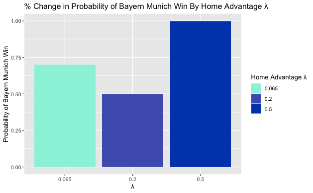

The above graph shows that even with a substantial home field advantage, `0.5`, the observed effect is only a 1% increase in their win rate across 1,000 competitions.

## Summary: Knockout Simulation with Domestic Strengths, Home Field Covariates

As seen throughout this section, our results suggest that the real outcome of the 2019-2020 UEFA Champions League knockouts somewhat follow the expectation of our models. Whether with domestic strengths, or domestic strengths and home pitch advantage, we saw that the likeliest final was Bayern Munich-Paris S-G, with PSG winning the bulk of the simulations.

## 2019-2020 UEFA Champions League Simulation

### Chances of each team winning tournament based on 10,000 simulations with two-legs in knockout rounds.

| Team | Win Tournament |
| --- | --- |
| Paris S-G | 0.4039 |
| Bayern Munich | 0.3125 |
| Manchester City | 0.1818 |
| Barcelona | 0.0457 |
| RB Leipzig | 0.0254 |
| Atlético Madrid | 0.0193 |
| Lyon | 0.0059 |
| Atalanta | 0.0055 |

### Chances of each team making tournament final based on 10,000 simulations with two-legs in knockout rounds.

| Team 1 | Team 2 | Made Final |
| --- | --- | --- |
| Paris S-G | Bayern Munich | 0.4297 |
| Paris S-G | Manchester City | 0.2769 |
| Paris S-G | Barcelona | 0.0716 |
| RB Leipzig | Bayern Munich | 0.0548 |
| Atlético Madrid | Bayern Munich | 0.0429 |
| RB Leipzig | Manchester City | 0.0319 |
| Atlético Madrid | Manchester City | 0.0279 |
| Paris S-G | Lyon | 0.0168 |
| Atalanta | Bayern Munich | 0.0154 |
| Atalanta | Manchester City | 0.0094 |

[output cut: 6 more lines]

### Challenges & Future Considerations

Throughout this section, we encountered several challenges that could see some improvement in the future. Namely, with fitting the Bradley-Terry models to the group stage, we saw significant deviations in team strengths, as well as missing values in model fitting due to the lack of team overlap in match-up results and a small sample size. Thus, our decisions to normalize the coefficients, as well as run several iterations of fitting to account for missing values may have skewed the team strengths somewhat. With that said, because our results aligned with those that played out in real life, there seems to be at least some merit to the process, including the use of domestic strengths as a covariate.

For future analyses of tournaments such as the UEFA Champions League, or other international competitions, it may be worthwhile to utilize simulations of not only the knockout stages, but also the group stages to observe a larger sample where deviations in results may be more evident. Further, a more detailed approach to breaking ties among aggregates could further differentiate our models from others, rather than utilizing the simplistic average goals-based Poisson model above.

Heuer, A., and et al. 2010. *Soccer: Is Scoring Goals a Predictable Poissonian Process?* No. 3. Vol. 89. https://iopscience.iop.org/article/10.1209/0295-5075/89/38007/pdf.

[^1]: Members from the following domestic leagues took part in the 2019-20 UEFA Champions League group stage: *Austrian Football Bundesliga, Belgian Pro League, Croatian Football League, Czech First League, English Premier League, French Ligue 1, German Fusball Bundesliga, Greek Super League, Italian Serie A, Dutch Eredivise, Portugese Premeira Liga, Russian Premier League, Serbian SuperLiga, Spanish La Liga, Turkish Super Lig, Ukrainian Premier League*
[^2]: Specific links and FBRef pages used can be found in the *GettingRawMatchupData.Rmd* notebook.
[^3]: https://en.wikipedia.org/wiki/2018%E2%80%9319_Russian_Premier_League#League_table